# Prédiction avec RandomForest

Thomas MASSÉ

18/12/2020

```r
library(randomForest)
library(tidyverse)
library(ggplot2)
library(dplyr)
#setwd("D:/R")
```

##### INTRODUCTION

[figure not shown]

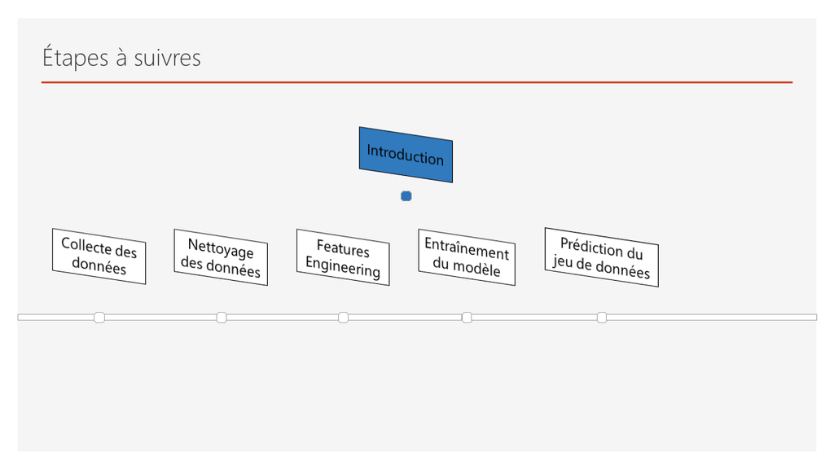

Nous allons voir ensemble comment utiliser le package RandomForest en R.  
Pour se faire on a souhaité réaliser le défi kaggle suivant : https://www.kaggle.com/c/pubg-finish-placement-prediction, il suffit de s’inscrire sur Kaggle pour pouvoir accéder aux jeux de données.

Dans une première partie nous verrons ce que sont les fôrets d’arbres aléatoires, dans une seconde on parcourera ensemble les différentes données à notre disposition et pour finir on utilisera RandomForest sur tout ceci.

##### LES FORETS D’ARBRES ALEATOIRES

Avant de comprendre les fôrets d’arbres aléatoires, il faut comprendre ce qu’est un arbre décisionnel.  
Un arbre décisionnel c’est tout simplement la représentation graphique sous forme d’arbres d’une suite de possibilités (ou de décisions).

On apelle chaque point un noeud et les liens entre les noeuds des branches.

Ce qui deviens intéressant c’est que l’on va pouvoir donner une probabilité à chaque décision.  
On va donc pouvoir utiliser le machine learning pour bâtir un arbre de décisions en se basant sur des données existantes et en donnant à chaque combinaison une probabilité.

Il y a 2 types d’arbres :

Arbres de régression, quand la variable dépendante (celle que l’on souhaite prédire) est continue.  
Arbres de classification, quand la variable dépendante est catégorielle. C’est ce que l’on utilisera dans notre exemple

Une fôret d’arbres aléatoires, c’est donc la création d’arbres de décisions de manières aléatoires en utilisant des données, ensuite de nouvelles données vont parcourir tout les arbres de notre modèle qui votent pour la classe de sortie (grâce à une moyenne pour la régression, ou par vote pour une classification).

J’ai essayé de vulgariser mais n’étant pas un expert je vous invite à consulter d’autres tutoriaux plus pointu sur ce sujet, si vous voulez plus entrez plus dans les détails.

##### QU’EST CE QUE PUBG ?

PUBG est l’abbréviation de PlayerUnknown’s Battlegrounds.  
C’est un jeu vidéo de type Battle Royale afin de mieux appréhender ce type de jeu vidéo si vous n’êtes pas familier je vous invite à consulter la vidéo suivante :

[figure not shown]

Je vous invite également à consulter du contenu sur twitch pour parfaire votre connaissance, je recommande notamment le stream de MoMaN qui joue régulièrement et est plutôt aguérri au genre ou il a fait ses armes depuis H1 Z1 (pour les plus connaisseurs)

##### EXPLICATIONS DES DONNEES

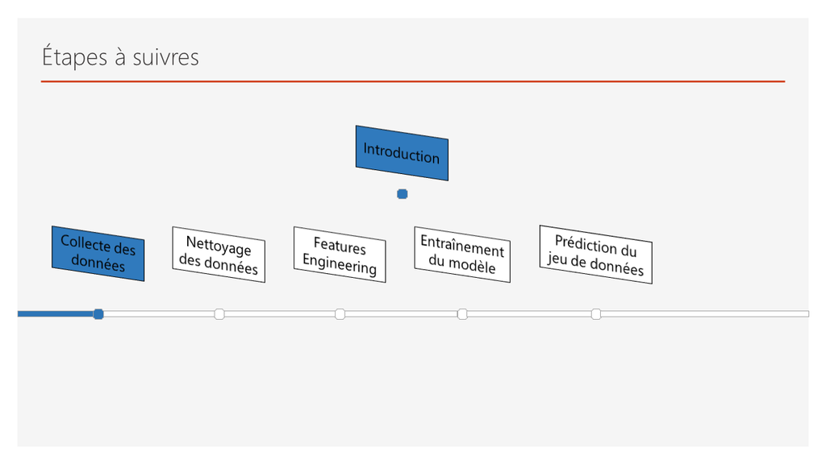

Collecte des données

Tout d’abord regardons les données que nous avons.

D’après la description sur Kaggle, nous avons les données de plus de 65000 parties séparés en jeu d’entraînement et jeu de test.  
Nous devons prédire les chances de victoires de chaque joueur en fonction des autres données.

Il y a 3 fichiers : - sample_submission_v2.csv : c’est l’exemple du format de soumission pour les concurrents qui ont réalisé le concours.  
- train_v2.csv : c’est notre jeu “d’entraînement”, c’est ce modèle qui va nous permettre de créer notre modèle de fôret d’arbres aléatoires.  
- test_v2.csv : c’est le jeu de données qui va parcourir le modèle et ou l’on va chercher à prédire une variable.

Nous allons donc lire les fichiers CSV

```r
#Lire le training set
trainsetPUBG <- read.csv2("D:/Dataset/PUBG/train_V2.csv",
                   sep = ",", header = TRUE, fileEncoding = "utf-8")
#Le mettre dans une dataframe
trainsetPUBG <- as.data.frame(trainsetPUBG)
#Afficher le nom des colonnes
colnames(trainsetPUBG)
```

```
##  [1] "Id"              "groupId"         "matchId"         "assists"
##  [5] "boosts"          "damageDealt"     "DBNOs"           "headshotKills"
##  [9] "heals"           "killPlace"       "killPoints"      "kills"
## [13] "killStreaks"     "longestKill"     "matchDuration"   "matchType"
## [17] "maxPlace"        "numGroups"       "rankPoints"      "revives"
## [21] "rideDistance"    "roadKills"       "swimDistance"    "teamKills"
## [25] "vehicleDestroys" "walkDistance"    "weaponsAcquired" "winPoints"
## [29] "winPlacePerc"
```

```r
#Lire le test set
testsetPUBG <- read.csv2("D:/Dataset/PUBG/test_V2.csv",
                   sep = ",", header = TRUE, fileEncoding = "utf-8")
#Le mettre dans une dataframe
testsetPUBG <- as.data.frame(testsetPUBG)
#Afficher le nom des colonnes
colnames(testsetPUBG)
```

```
##  [1] "Id"              "groupId"         "matchId"         "assists"
##  [5] "boosts"          "damageDealt"     "DBNOs"           "headshotKills"
##  [9] "heals"           "killPlace"       "killPoints"      "kills"
## [13] "killStreaks"     "longestKill"     "matchDuration"   "matchType"
## [17] "maxPlace"        "numGroups"       "rankPoints"      "revives"
## [21] "rideDistance"    "roadKills"       "swimDistance"    "teamKills"
## [25] "vehicleDestroys" "walkDistance"    "weaponsAcquired" "winPoints"
```

On voit bien qu’entre les 2 jeux de données nous avons les mêmes variables, moyennant bien sûr une seule, notre variable à prédire (winPlacePerc) qui est présente uniquement dans le jeu d’entraînement.

##### Explication des variables

**Id** = C’est l’identifiant unique du joueur  
**groupId** = C’est l’identifiant du groupe du joueur, selon le type de partie nous pouvons jouer tout seul, à 2 ou à 4.  
**matchId** = C’est l’identifiant unique du match  
**assists** = Le nombre d’assistances, une assistance c’est quand l’on touche un autre joueur mais que c’est un autre joueur (ami ou ennemi) qui mets la dernière balle pour le finir.  
**boosts** = Le nombres de **boosts** pris par le joueur. Les **boosts** sont des éléments qui permettent de se régénérer un petit peu de vie et de se déplacer plus vite. **damageDealt** = Le nombre de dégâts réalisé, 1 point de vie enlevé à un ennemi correspont à 1 point de dégat.  
**DBNOs** = Le nombre d’ennemi que l’on a mis K.O, dans les parties en équipes avant de mourrir on a un état supplémentaire qui est K.O, les alliés ont alors quelques secondes pour réanimer leurs allié ou les ennemis pour le finir.  
**headshotKills** = Le nombre de personne tués d’un tir dans la tête  
**heals** = Le nombre de soins utilisés  
**killPlace** = C’est le placement dans la partie du joueur d’un point de vue de **kills**  
**killPoints** = Un peu comme un ELO (score aux echecs par exemple) d’un point de vue des **kills** uniquement  
**kills** = Le nombre de personnes tués  
**killStreaks** = Nombres de personnes tués lors d’un enchaînement (quelques secondes pour enchaîner)  
**longestKill** = Distance en m, c’est la distance à laquelle un joueur à réalisé un kill du plus loin  
**matchDuration** = Durée du match  
**matchType** = Type du match, solo duo ou squad ainsi que la carte  
**maxPlace** = Plus mauvais placement d’un joueur  
**numGroups** = Nombre de groupes  
**rankPoints** = Un peu comme un ELO d’un point de vue des points de classement uniquement.  
**revives** = Nombres de fois ou on a relevé (de l’état de KO) des équipiers.  
**rideDistance** = Distance (en m) parcouru en véhicule  
**roadKills** = Nombres de personnes tués en véhicule  
**swimDistance** = Distance (en m) parcouru à la nage  
**teamKills** = Nombre d’alliers que le joueur à tué  
**vehicleDestroys** = Nombre de véhicule détruit  
**walkDistance** = Distance (en m) parcouru à pieds  
**weaponsAcquired** = Nombre d’armes ramassés  
**winPoints** = Un peu comme un ELO d’un point de vue des victoires uniquement  
**winPlacePerc** = C’est le pourcentage de chance d’un joueur de remporter la partie, c’est également la variable que l’on cherche à prédire

##### Analyse et nettoyage des données

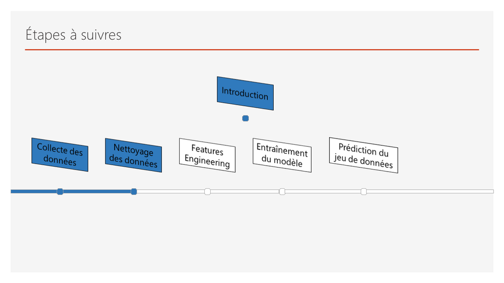

```r
summary(trainsetPUBG)
```

```
##       Id              groupId            matchId             assists
##  Length:4446966     Length:4446966     Length:4446966     Min.   : 0.0000
##  Class :character   Class :character   Class :character   1st Qu.: 0.0000
##  Mode  :character   Mode  :character   Mode  :character   Median : 0.0000
##                                                           Mean   : 0.2338
##                                                           3rd Qu.: 0.0000
##                                                           Max.   :22.0000
##      boosts       damageDealt            DBNOs         headshotKills
##  Min.   : 0.000   Length:4446966     Min.   : 0.0000   Min.   : 0.0000
##  1st Qu.: 0.000   Class :character   1st Qu.: 0.0000   1st Qu.: 0.0000
##  Median : 0.000   Mode  :character   Median : 0.0000   Median : 0.0000
##  Mean   : 1.107                      Mean   : 0.6579   Mean   : 0.2268
##  3rd Qu.: 2.000                      3rd Qu.: 1.0000   3rd Qu.: 0.0000
##  Max.   :33.000                      Max.   :53.0000   Max.   :64.0000
##      heals         killPlace       killPoints       kills
##  Min.   : 0.00   Min.   :  1.0   Min.   :   0   Min.   : 0.0000
##  1st Qu.: 0.00   1st Qu.: 24.0   1st Qu.:   0   1st Qu.: 0.0000
##  Median : 0.00   Median : 47.0   Median :   0   Median : 0.0000
##  Mean   : 1.37   Mean   : 47.6   Mean   : 505   Mean   : 0.9248
##  3rd Qu.: 2.00   3rd Qu.: 71.0   3rd Qu.:1172   3rd Qu.: 1.0000
##  Max.   :80.00   Max.   :101.0   Max.   :2170   Max.   :72.0000
##   killStreaks     longestKill        matchDuration   matchType
##  Min.   : 0.000   Length:4446966     Min.   :   9   Length:4446966
##  1st Qu.: 0.000   Class :character   1st Qu.:1367   Class :character
##  Median : 0.000   Mode  :character   Median :1438   Mode  :character
##  Mean   : 0.544                      Mean   :1580
##  3rd Qu.: 1.000                      3rd Qu.:1851
##  Max.   :20.000                      Max.   :2237
##     maxPlace       numGroups        rankPoints      revives
##  Min.   :  1.0   Min.   :  1.00   Min.   :  -1   Min.   : 0.0000
##  1st Qu.: 28.0   1st Qu.: 27.00   1st Qu.:  -1   1st Qu.: 0.0000
##  Median : 30.0   Median : 30.00   Median :1443   Median : 0.0000
##  Mean   : 44.5   Mean   : 43.01   Mean   : 892   Mean   : 0.1647
##  3rd Qu.: 49.0   3rd Qu.: 47.00   3rd Qu.:1500   3rd Qu.: 0.0000
##  Max.   :100.0   Max.   :100.00   Max.   :5910   Max.   :39.0000
##  rideDistance         roadKills         swimDistance         teamKills
##  Length:4446966     Min.   : 0.000000   Length:4446966     Min.   : 0.00000
##  Class :character   1st Qu.: 0.000000   Class :character   1st Qu.: 0.00000
##  Mode  :character   Median : 0.000000   Mode  :character   Median : 0.00000
##                     Mean   : 0.003496                      Mean   : 0.02387
##                     3rd Qu.: 0.000000                      3rd Qu.: 0.00000
##                     Max.   :18.000000                      Max.   :12.00000
##  vehicleDestroys    walkDistance       weaponsAcquired    winPoints
##  Min.   :0.000000   Length:4446966     Min.   :  0.00   Min.   :   0.0
##  1st Qu.:0.000000   Class :character   1st Qu.:  2.00   1st Qu.:   0.0
##  Median :0.000000   Mode  :character   Median :  3.00   Median :   0.0
##  Mean   :0.007918                      Mean   :  3.66   Mean   : 606.5
##  3rd Qu.:0.000000                      3rd Qu.:  5.00   3rd Qu.:1495.0
##  Max.   :5.000000                      Max.   :236.00   Max.   :2013.0
##  winPlacePerc
##  Length:4446966
##  Class :character
##  Mode  :character
##
##
##
```

Première constatation il y a des colonnes qui sont en *character* alors qu’elles sont constitués de valeurs numérique : - DamageDealt  
- longestKill  
- rideDistance  
- swimDistance  
- walkDistance  
- winPlacePerc

Nous allons donc transformer ces colonnes en valeurs numériques.

```r
trainsetPUBG$winPlacePerc <- as.numeric(trainsetPUBG$winPlacePerc)
trainsetPUBG$damageDealt <- as.numeric(trainsetPUBG$damageDealt)
trainsetPUBG$longestKill <- as.numeric(trainsetPUBG$longestKill)
trainsetPUBG$rideDistance <- as.numeric(trainsetPUBG$rideDistance)
trainsetPUBG$swimDistance <- as.numeric(trainsetPUBG$swimDistance)
trainsetPUBG$walkDistance <- as.numeric(trainsetPUBG$walkDistance)
```

Afin que notre jeu de données soit le plus précis possible regardons de plus près chaque variable et essayons de detecter d’éventuelles problèmes ou tout simplement valeur que l’on souhaite regarder de plus près.  
- 53 **DBNOs** alors que la moyenne est de 0.6579  
- 64 **headshotKills** alors que la moyenne est de 0.2268  
- 80 **heals** alors que 3/4 des valeurs sont en dessous de 2  
- 101 **killPlace** alors que le maximum de joueurs est de 100, le maximum de killPlace devrait aussi être de 100. On regardera cette valeur de plus près pour essayer de voir si c’est un bug ou si il y a bien eu une partie à 101 joueurs.  
- 72 **kills** quand la moyenne est égale à 0.9248  
- 20 **killStreaks**, de ma connaissance du jeu il me parait impossible de réaliser un enchaînement de 20 joueurs la aussi on va regarder de plus près pour voir si on detecte une anomalie.  
- 39 **revives** pour une moyenne de 0.1647  
- 40710 **rideDistance** pour une moyenne de 606.12, de plus la aussi la zone se réduisant tout de même rapidement il me paraît difficile de parcourir 40km sans avoir croisé un alpha.  
- 18 **roadKills** pour une moyenne de 0.003496, également ici il me paraît difficile d’écraser 18 joueurs sans tomber sur plus fort ou plus malin que soi.  
- 25780 **walkDistance** comme pour la rideDistance 25.7 km a pieds semble beaucoup trop. Surtout le comportement d’un bon joueur même si très mobile reste de très bien se placer et de profiter de placement avantageux pour prendre le dessus sur ces adversaires.  
- 236 **weaponsAcquired**, la encore comment ramasser 236 armes en une seule partie?  
- **winPlacePerc**, une valeur N/A dans la colonne winPlacePerc n’est pas souhaitable, nous allons donc supprimer cette ligne de la dataframe.

Certaines des valeurs plus haut mène à réflexion, afin de pouvoir mieux visualiser si ce sont des valeurs vraiment extrême (liès à des cheateurs par exemple) ou si ce sont juste des très bon joueurs.

Pour cela on va imprimer les graphes de ses variables afin de mieux le visualiser.

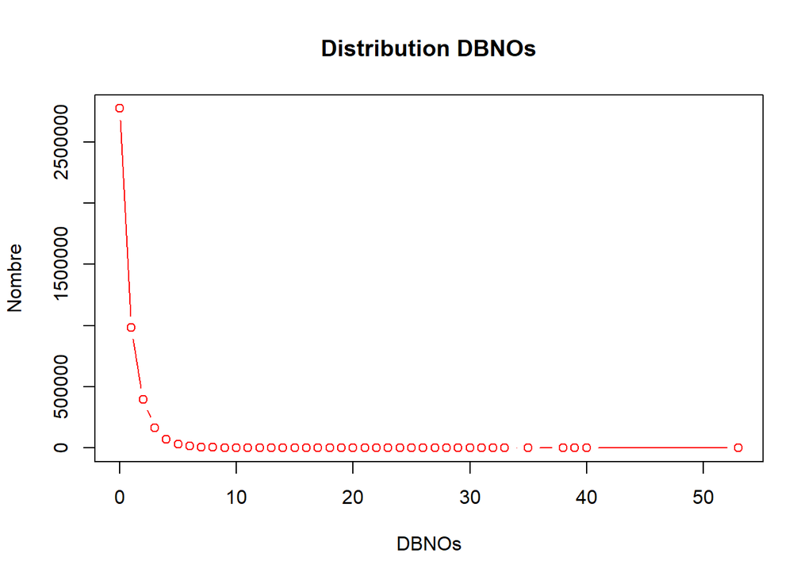

```r
distributionDBNOs <- count(trainsetPUBG, vars=DBNOs)
plot(distributionDBNOs, type="b", col="red", main="Distribution DBNOs", xlab="DBNOs", ylab="Nombre")
```

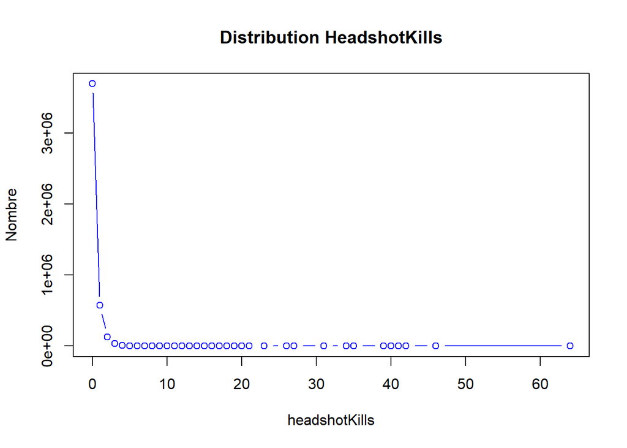

```r
#plot(trainsetPUBG$headshotKills)
distributionHS <- count(trainsetPUBG, vars=headshotKills)
plot(distributionHS, type="b", col="blue", main="Distribution HeadshotKills", xlab="headshotKills", ylab="Nombre")
```

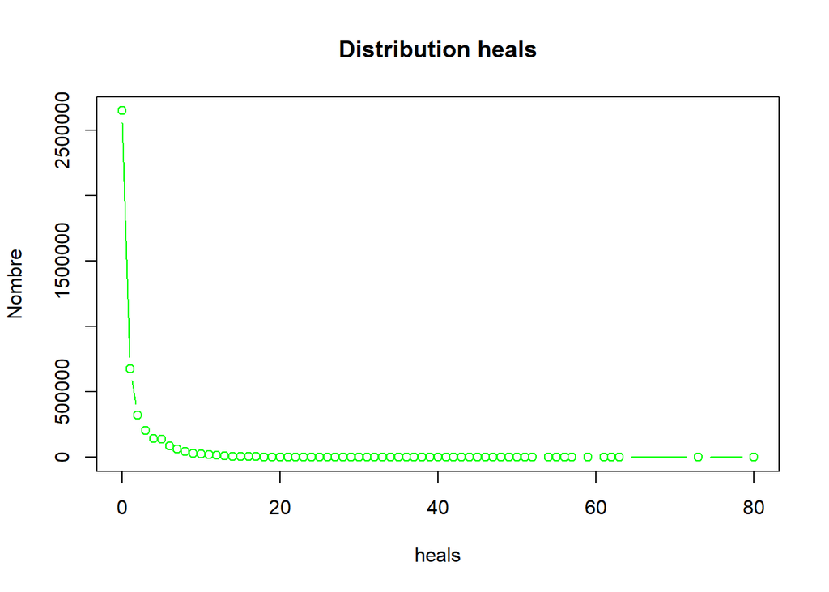

```r
#plot(trainsetPUBG$heals)
distributionHeals <- count(trainsetPUBG, vars=heals)
plot(distributionHeals, type="b", col="green", main="Distribution heals", xlab="heals", ylab="Nombre")
```

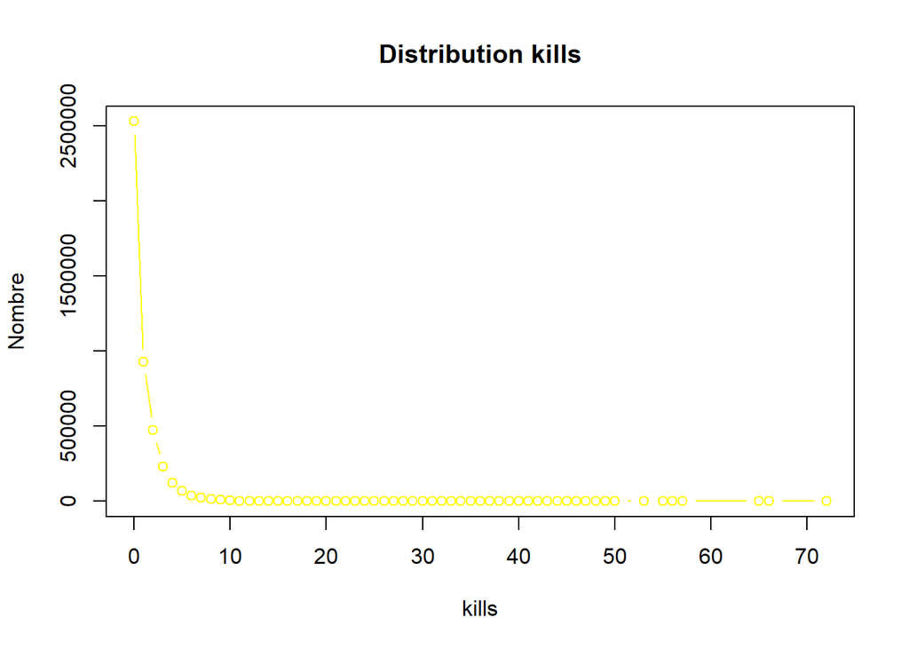

```r
#plot(trainsetPUBG$kills)
distributionKills <- count(trainsetPUBG, vars=kills)
plot(distributionKills, type="b", col="yellow", main="Distribution kills", xlab="kills", ylab="Nombre")
```

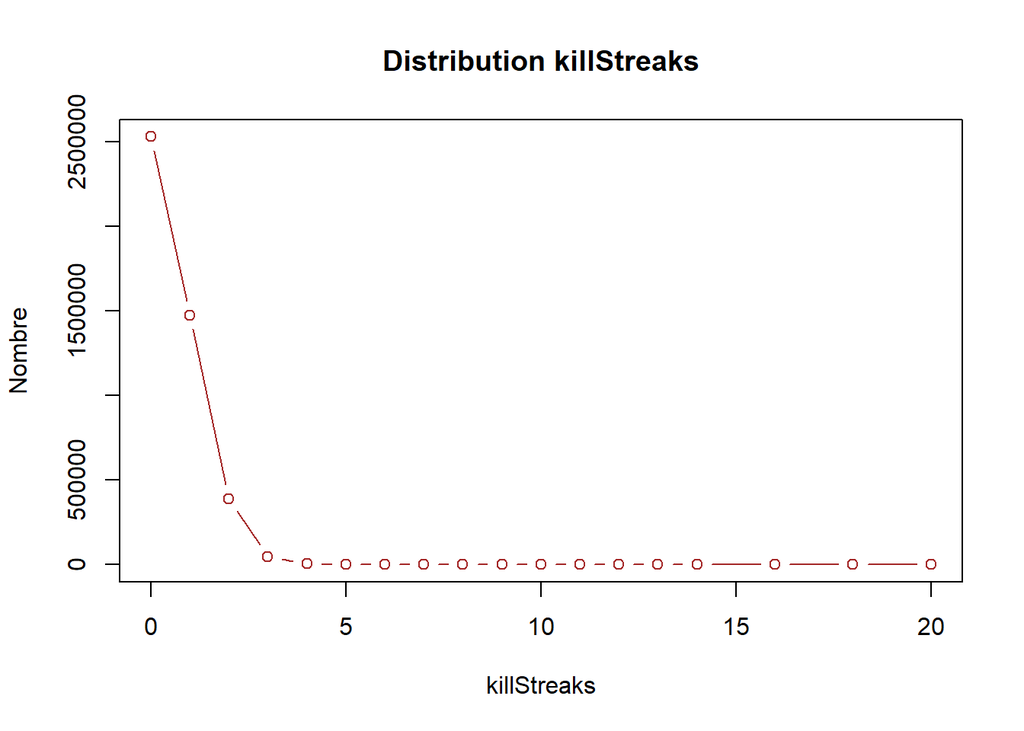

```r
#plot(trainsetPUBG$killStreaks)
distributionkillStreaks <- count(trainsetPUBG, vars=killStreaks)
plot(distributionkillStreaks, type="b", col="brown", main="Distribution killStreaks", xlab="killStreaks", ylab="Nombre")
```

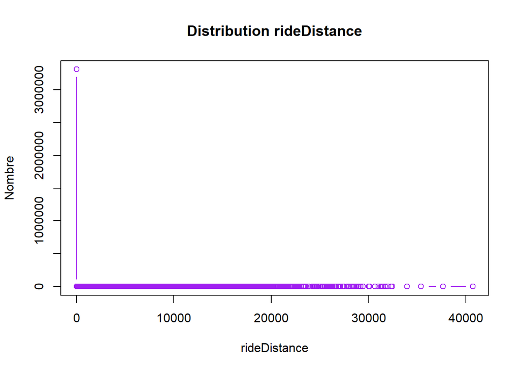

```r
#plot(trainsetPUBG$rideDistance)
distributionRideDistance <- count(trainsetPUBG, vars=rideDistance)
plot(distributionRideDistance, type="b", col="purple", main="Distribution rideDistance", xlab="rideDistance", ylab="Nombre")
```

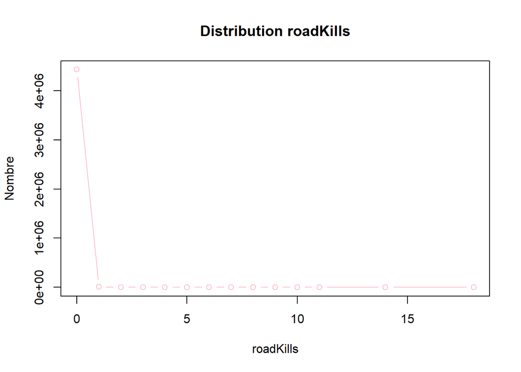

```r
#plot(trainsetPUBG$roadKills)
distributionRoadKills <- count(trainsetPUBG, vars=roadKills)
plot(distributionRoadKills, type="b", col="pink", main="Distribution roadKills", xlab="roadKills", ylab="Nombre")
```

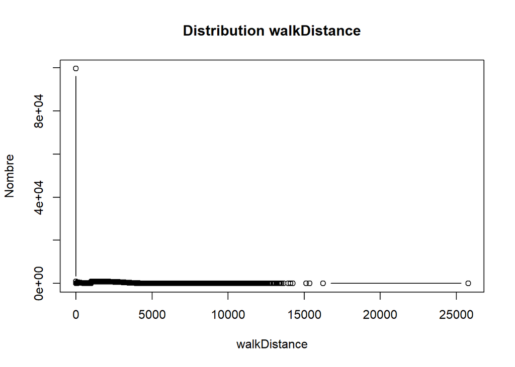

```r
#plot(trainsetPUBG$walkDistance)
distributionWalkDistance <- count(trainsetPUBG, vars=walkDistance)
plot(distributionWalkDistance, type="b", col="black", main="Distribution walkDistance", xlab="walkDistance", ylab="Nombre")
```

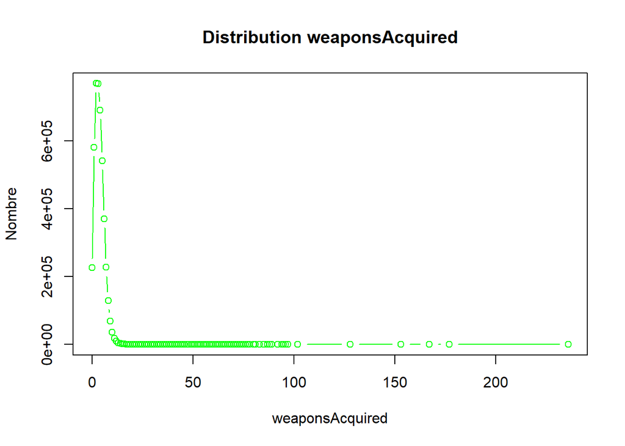

```r
#plot(trainsetPUBG$weaponsAcquired)
distributionWeaponsAcquired <- count(trainsetPUBG, vars=weaponsAcquired)
plot(distributionWeaponsAcquired, type="b", col="green", main="Distribution weaponsAcquired", xlab="weaponsAcquired", ylab="Nombre")
```

Avec un graphique rapide bien que sommaire on voit très bien la distribution, la valeur max de 53 paraît encore plus étonnant, on va étudier ça de plus près.  
Tout d’abord en regardant les lignes de la dataframe pour lequel le **DBNOs** est supérieur à 40.

```r
DBNOs = trainsetPUBG[trainsetPUBG$DBNOs > 40, ]
print(DBNOs)
```

```
##                     Id        groupId        matchId assists boosts damageDealt
## 3673966 f83f0bfaafb7d8 22d80bf00f56b7 fc0bbecba8db99       2      1        5330
##         DBNOs headshotKills heals killPlace killPoints kills killStreaks
## 3673966    53            41    21         1       1000    55          14
##         longestKill matchDuration        matchType maxPlace numGroups
## 3673966       310.3          1796 normal-squad-fpp       11        11
##         rankPoints revives rideDistance roadKills swimDistance teamKills
## 3673966         -1       0            0         0            0         0
##         vehicleDestroys walkDistance weaponsAcquired winPoints winPlacePerc
## 3673966               0        12.19              17      1500            1
```

La encore en regardant la ligne dans son ensemble, ç’est étrange le joueur **f83f0bfaafb7d8** à réaliser 55 **kills** en parcourant seulement 12.19m.

Intéressant nous maintenant aux **headshotKills**, regardons également les valeurs au dessus de 40 pour voir si on a à faire à d’excellent joueur ou des tricheurs.

```r
HSKills = trainsetPUBG[trainsetPUBG$headshotKills > 40, ]
print(HSKills)
```

```
##                     Id        groupId        matchId assists boosts damageDealt
## 1454066 c47bd86daa3de6 4df3e348b910d8 3ebf1bf8bc6bae       2      2        4495
## 2020832 9b5bcc3a3dd42a bdd2cf09863501 6bf647ecee30da       2      0        4889
## 3431248 06308c988bf0c2 4c4ee1e9eb8b5e 6680c7c3d17d48       7      4        5990
## 3673966 f83f0bfaafb7d8 22d80bf00f56b7 fc0bbecba8db99       2      1        5330
##         DBNOs headshotKills heals killPlace killPoints kills killStreaks
## 1454066     0            42     2         1       1000    50           7
## 2020832     0            46     2         1          0    53          10
## 3431248     0            64    10         1          0    72           7
## 3673966    53            41    21         1       1000    55          14
##         longestKill matchDuration        matchType maxPlace numGroups
## 1454066      324.20          1136  normal-solo-fpp       30        17
## 2020832      690.40           833 normal-squad-fpp       13        13
## 3431248       78.23          1800     normal-squad       15        15
## 3673966      310.30          1796 normal-squad-fpp       11        11
##         rankPoints revives rideDistance roadKills swimDistance teamKills
## 1454066         -1       0            0         0            0         0
## 2020832       1500       0            0         0            0         0
## 3431248       1500       0            0         0            0         0
## 3673966         -1       0            0         0            0         0
##         vehicleDestroys walkDistance weaponsAcquired winPoints winPlacePerc
## 1454066               0      1021.00              15      1500            1
## 2020832               0       272.30              14         0            1
## 3431248               0       728.10              35         0            1
## 3673966               0        12.19              17      1500            1
```

Sans surprise on retrouve notre ami **f83f0bfaafb7d8** mais ce n’est pas lui qui à le plus de **headshotKills**.  
Difficile de trancher ici, il est possible que ces 3 joueurs ne soit pas des tricheurs.

Jettons un coup d’oeil aux autres valeurs maximum étrange en utilisant la même méthode

```r
heals = trainsetPUBG[trainsetPUBG$heals > 60, ]
print(heals)
```

```
##                     Id        groupId        matchId assists boosts damageDealt
## 700616  512ca0f7c6729b de2c3988154e5e 03a24daa0f3e65       0      3       0.000
## 996710  6737eed1cf8dfc 12cc81f7d2eb4d 5f9a59a3ef190d       0      6       1.824
## 3419346 4d6c412604232f ff7daf14a68de4 fea1354b6e5089       1      8     146.700
## 3476344 1ac3c7d24475c8 ea7008368b4c5d fcc78beee326e3       1      4     207.200
## 4262663 3be1ded892f443 5c6c4e66418c25 ce09de37cf3f5a       0      1     230.000
## 4397806 703ce5805efed7 b84c7dd65f03cd d8fa2223c98979       0      1      44.510
##         DBNOs headshotKills heals killPlace killPoints kills killStreaks
## 700616      3             0    61        48          0     0           0
## 996710      0             0    63        37       1025     0           0
## 3419346     0             0    61        30       1402     1           1
## 3476344     0             0    73        26          0     1           1
## 4262663     5             0    80        41       1440     0           0
## 4397806     0             0    62        44          0     0           0
##         longestKill matchDuration matchType maxPlace numGroups rankPoints
```

[output cut: 20 more lines]

```r
kills = trainsetPUBG[trainsetPUBG$kills > 60, ]
print(kills)
```

```
##                     Id        groupId        matchId assists boosts damageDealt
## 334401  810f2379261545 7f3e493ee71534 f900de1ec39fa5      20      0        6616
## 1248349 80ac0bbf58bfaf 1e54ab4540a337 08e4c9e6c033e2       5      0        6375
## 3431248 06308c988bf0c2 4c4ee1e9eb8b5e 6680c7c3d17d48       7      4        5990
##         DBNOs headshotKills heals killPlace killPoints kills killStreaks
## 334401      0            13     5         1          0    65           7
## 1248349     0            21     4         1          0    66           8
## 3431248     0            64    10         1          0    72           7
##         longestKill matchDuration       matchType maxPlace numGroups rankPoints
## 334401        73.90          1798 normal-solo-fpp       11        11       1500
## 1248349      319.90          1390 normal-solo-fpp       18        12       1500
## 3431248       78.23          1800    normal-squad       15        15       1500
##         revives rideDistance roadKills swimDistance teamKills vehicleDestroys
## 334401        0            0         0            0         0               0
## 1248349       0            0         0            0         0               0
## 3431248       0            0         0            0         0               0
##         walkDistance weaponsAcquired winPoints winPlacePerc
## 334401        1036.0              60         0            1
## 1248349       1740.0              23         0            1
## 3431248        728.1              35         0            1
```

```r
killstreak = trainsetPUBG[trainsetPUBG$killStreaks > 15, ]
print(killstreak)
```

```
##                     Id        groupId        matchId assists boosts damageDealt
## 2714365 df578079868527 c9dab2739e98a5 367dd0033fae50       0      0        1683
## 2890741 a3438934e3e535 1081c315a80d14 fe744430ac0070       0      8        2074
## 3924730 579949f753978c 108f4c00d80882 ff9cd80c0d8fb7       1      2        3680
##         DBNOs headshotKills heals killPlace killPoints kills killStreaks
## 2714365     0             5     0         1       1000    16          16
## 2890741     0             1    11         1       1114    20          18
## 3924730     0            35     0         1       1000    40          20
##         longestKill matchDuration        matchType maxPlace numGroups
## 2714365       7.395          1367             solo       94        74
## 2890741      64.290          1970             solo       38        20
## 3924730     621.800           799 normal-squad-fpp       10        10
##         rankPoints revives rideDistance roadKills swimDistance teamKills
## 2714365         -1       0            0         0            0         0
## 2890741         -1       0         2726        18            0         0
## 3924730         -1       0            0         0            0         0
##         vehicleDestroys walkDistance weaponsAcquired winPoints winPlacePerc
## 2714365               0          258               2      1500       0.4624
## 2890741               0         3150               4      1568       1.0000
## 3924730               0         1180               2      1500       1.0000
```

```r
rideD = trainsetPUBG[trainsetPUBG$rideDistance > 30000, ]
print(rideD)
```

```
##                     Id        groupId        matchId assists boosts damageDealt
## 426709  149e224a2330ae 6d8cb80b3de8ff f8b8e2643f60ee       0      2       0.000
## 605624  8dee54600c67ca e77f3e175b5959 26bc606cdae6bf       0      0      11.210
## 1214638 470dca70fbef4d d44161e5d29c1a c7d52d5aaff270       0      0     127.300
## 1232005 2c5add87b29a8c 1d9d7faa352311 ef2ae297b170f3       0      7     196.900
## 1232363 4bf27787223351 b0140dd17f3238 5ed9c405f7e71d       0      1       0.000
## 1361248 f09d0c99127850 4ca387960d74a7 93aa204e9c193e       0      2     265.600
## 1713774 239905dd1f3787 da3d922a92ace5 692bd6a11b86c8       0      0     141.200
## 1725338 9f14f77b6dd9b6 8a2a8ae2506323 904b5fa7f59bc5       0      2       2.389
## 2137064 73b793b4e7523f f4444641af7e5c 6385f7641268c3       0      0       0.000
## 2700692 3428324a089608 fa77b4ac736dbf 9b1c87f4016f47       0      1      31.270
## 2927409 260efc0cf6b36c b112f8d21e8185 3e977510ce1d3c       0      0      11.220
## 3404579 8e84f4228e5436 c5ca5892142cbd 56775920f704e8       0      0       3.298
## 3567266 99f342c6022411 9158efebffecc7 ddbe41fe165c7f       2      2     113.200
## 4099939 afe34618b04d77 c14f532b283844 732c3b752e055f       0      0       0.000
```

[output cut: 75 more lines]

```r
roadK = trainsetPUBG[trainsetPUBG$roadKills > 10, ]
print(roadK)
```

```
##                     Id        groupId        matchId assists boosts damageDealt
## 2733927 c3e444f7d1289f 489dd6d1f2b3bb 4797482205aaa4       0      0        1246
## 2768000 34193085975338 bd7d50fa305700 a22354d036b3d6       0      0        1102
## 2890741 a3438934e3e535 1081c315a80d14 fe744430ac0070       0      8        2074
## 3524414 9d9d044f81de72 8be97e1ba792e3 859e2c2db5b125       0      3        1866
##         DBNOs headshotKills heals killPlace killPoints kills killStreaks
## 2733927     0             0     0         1       1403    14          13
## 2768000     0             0     0         1       1497    11          11
## 2890741     0             1    11         1       1114    20          18
## 3524414     0             5     7         1       1520    18          11
##         longestKill matchDuration matchType maxPlace numGroups rankPoints
## 2733927       7.181          1456      solo       92        80         -1
## 2768000       0.000          1946      solo       88        77         -1
## 2890741      64.290          1970      solo       38        20         -1
## 3524414     341.400          1925      solo       84        70         -1
##         revives rideDistance roadKills swimDistance teamKills vehicleDestroys
## 2733927       0        0.005        14        5.297         0               0
## 2768000       0     4118.000        11        0.000         0               0
## 2890741       0     2726.000        18        0.000         0               0
## 3524414       0     6812.000        11        0.000         0               0
##         walkDistance weaponsAcquired winPoints winPlacePerc
## 2733927       1277.0               0      1371       0.4286
## 2768000        816.6               5      1533       0.4713
## 2890741       3150.0               4      1568       1.0000
## 3524414       1041.0              10      1606       0.9398
```

```r
walkD = trainsetPUBG[trainsetPUBG$walkDistance > 15000, ]
print(walkD)
```

```
##                     Id        groupId        matchId assists boosts damageDealt
## 497966  3304d0c68e27f5 503757159d22dd ce88f9c8c35bdf       0      0         0.0
## 1797163 7b9a750b17e9c6 2d00192e4029c5 6fe77402ddb0e1       0      0         0.0
## 2238901 861d1e5a63f3e6 1da6a90addf96d 16f2c51578f323       0      1         0.0
## 2395010 d6d37216c02c17 56dd8821cacb32 f27850950d5597       0      3       273.3
##         DBNOs headshotKills heals killPlace killPoints kills killStreaks
## 497966      0             0     0        46          0     0           0
## 1797163     0             0     0        55          0     0           0
## 2238901     0             0     5        46          0     0           0
## 2395010     0             0     1        11       1300     2           1
##         longestKill matchDuration matchType maxPlace numGroups rankPoints
## 497966          0.0          1889  solo-fpp       95        93       1520
## 1797163         0.0          1977 squad-fpp       26        25       1482
## 2238901         0.0          1828      solo       97        95       1651
## 2395010       136.8          1932  solo-fpp       97        93         -1
##         revives rideDistance roadKills swimDistance teamKills vehicleDestroys
## 497966        0       0.0078         0       381.90         0               0
## 1797163       0       0.0401         0       129.40         0               0
## 2238901       0       0.0111         0       389.50         0               0
## 2395010       0    1575.0000         0        59.05         0               0
##         walkDistance weaponsAcquired winPoints winPlacePerc
## 497966         25780               0         0       0.9894
## 1797163        16250               3         0       0.6000
## 2238901        15370               7         0       0.8125
## 2395010        15130               3      1583       1.0000
```

```r
wA = trainsetPUBG[trainsetPUBG$weaponsAcquired > 150, ]
print(wA)
```

```
##                     Id        groupId        matchId assists boosts damageDealt
## 2743409 afcb46681b909f 3715298b7eea9c 4dd4d42772464f       0      4      186.90
## 2749694 940b52bf12805a 4757d102ca4fbf 7ecae2cedc064f       1      3      378.90
## 2797868 da68d2812229a8 536975608768ed fbbdc018f4b771       0      0        0.00
## 2982526 3f2bcf53b108c4 2dbc013e849f5a 1df2560f0937ab       0      1       85.85
##         DBNOs headshotKills heals killPlace killPoints kills killStreaks
## 2743409     2             0     2        18       1288     2           2
## 2749694     2             0     5         7       1791     3           1
## 2797868     0             0     0        58          0     0           0
## 2982526     0             0     2        55       1664     0           0
##         longestKill matchDuration matchType maxPlace numGroups rankPoints
## 2743409       33.43          1511       duo       45        45         -1
## 2749694      140.50          1400 squad-fpp       27        26         -1
## 2797868        0.00          1793  solo-fpp       98        95       1527
## 2982526        0.00          1928 squad-fpp       29        28         -1
##         revives rideDistance roadKills swimDistance teamKills vehicleDestroys
## 2743409       0       1675.0         0            0         1               0
## 2749694       0        303.7         0            0         0               0
## 2797868       0          0.0         0            0         0               0
## 2982526       0       4778.0         0            0         0               0
##         walkDistance weaponsAcquired winPoints winPlacePerc
## 2743409         1643             167      1452       0.7955
## 2749694         3338             177      1711       0.8846
## 2797868         1235             153         0       0.5464
## 2982526         2112             236      1553       0.6786
```

Difficile de trancher mais tout paraît bien legitime.  
On va juste supprimer la ligne de notre ami tricheur et la ligne avec la valeur **N/A**.

```r
#Nombres de lignes dans la DataFrame
nrow(trainsetPUBG)
```

```
## [1] 4446966
```

```r
trainsetPUBG <- subset(trainsetPUBG, Id!="f83f0bfaafb7d8")
#Nombres de lignes dans la DataFrame
nrow(trainsetPUBG)
```

```
## [1] 4446965
```

```r
trainsetPUBG <- trainsetPUBG[!is.na(trainsetPUBG$winPlacePerc),]
#Nombres de lignes dans la DataFrame
nrow(trainsetPUBG)
```

```
## [1] 4446964
```

Tout s’est bien déroulé on a bien supprimer seulement les 2 lignes qu’on souhaitait.

##### Un peu de features engineering

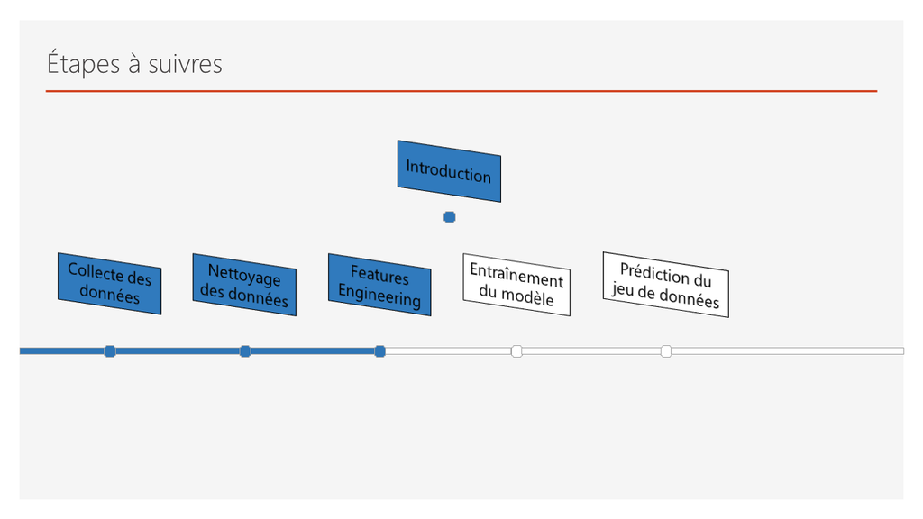

Ici nous allons le faire plus dans un soucis de réduire le nombres de variables que dans un réel soucis d’éfficacité, mais on va au maximum essayer de faire les 2.  
Il y a pas mal de variables rédondantes, on va donc créer une colonne **distanceParcouru** qui sera la distance totale parcouru par le joueur.  
On va également créer une colonne **healsBoosts** qui sera la somme de ces 2 consommables.  
Les tirs à la tête nécessitant beaucoup plus de skills que les **kills** classique on va rajouter cette colonne, on ne supprimera pas les colonnes car on veux quand même pouvoir étudier les **kills** et **headshotKills** indépendament.

```r
trainsetPUBG$DistanceParcouru = trainsetPUBG$rideDistance + trainsetPUBG$swimDistance + trainsetPUBG$walkDistance
trainsetPUBG$healsBoosts = trainsetPUBG$heals + trainsetPUBG$boosts
trainsetPUBG$HSratio = trainsetPUBG$headshotKills / trainsetPUBG$kills
trainsetPUBG$GlobalPoints = trainsetPUBG$winPoints + trainsetPUBG$killPoints + trainsetPUBG$rankPoints
trainsetPUBG$KDA = trainsetPUBG$kills + trainsetPUBG$assists/3 + trainsetPUBG$roadKills
#suppression des colonnes désormais inutile
trainsetPUBG = trainsetPUBG[, !(colnames(trainsetPUBG) %in% c("rideDistance","swimDistance","walkDistance","heals","boosts","Id","groupId","matchId","assists","winPoints","killPoints","rankPoints","roadKills"))]
trainsetPUBG[is.na(trainsetPUBG)] <- 0
head(trainsetPUBG, 10)
```

```
##    damageDealt DBNOs headshotKills killPlace kills killStreaks longestKill
## 1        0.000     0             0        60     0           0        0.00
## 2       91.470     0             0        57     0           0        0.00
## 3       68.000     0             0        47     0           0        0.00
## 4       32.900     0             0        75     0           0        0.00
## 5      100.000     0             0        45     1           1       58.53
## 6      100.000     1             1        44     1           1       18.44
## 7        0.000     0             0        96     0           0        0.00
## 8        8.538     0             0        48     0           0        0.00
## 9       51.600     0             0        64     0           0        0.00
## 10      37.270     0             0        74     0           0        0.00
##    matchDuration matchType maxPlace numGroups revives teamKills vehicleDestroys
## 1           1306 squad-fpp       28        26       0         0               0
## 2           1777 squad-fpp       26        25       0         0               0
## 3           1318       duo       50        47       0         0               0
```

[output cut: 29 more lines]

```r
vSolo <- c('flarefpp','flaretpp','crashfpp','crashtpp','normal-solo','normal-solo-fpp','solo-fpp')
trainsetSolo <- filter(trainsetPUBG, matchType %in% vSolo)
vDuo <- c('duo-fpp','normal-duo','normal-duo-fpp')
trainsetDuo <- filter(trainsetPUBG, matchType %in% vDuo)
vSquad <- c('normal-squad','normal-squad-fpp','squad-fpp')
trainsetSquad <- filter(trainsetPUBG, matchType %in% vSquad)
nrow(trainsetSolo)
```

```
## [1] 548650
```

```r
nrow(trainsetDuo)
```

```
## [1] 1002379
```

```r
nrow(trainsetSquad)
```

```
## [1] 1773875
```

```r
trainsetSolo = trainsetSolo[, !(colnames(trainsetSolo) %in% c("groupId","DBNOs","matchType","numGroups","revives","teamKills"))]
head(trainsetSolo, 10)
```

```
##    damageDealt headshotKills killPlace kills killStreaks longestKill
## 1      100.000             0        45     1           1       58.53
## 2        8.538             0        48     0           0        0.00
## 3      324.200             1         5     4           1       49.83
## 4      254.300             0        13     2           1       36.00
## 5      136.900             0        37     1           1       22.83
## 6      194.500             1        19     2           1       29.08
## 7      100.000             1        29     1           1       21.86
## 8       46.410             0        81     0           0        0.00
## 9      604.700             2         4     5           1       99.23
## 10      76.440             0        50     0           0        0.00
##    matchDuration maxPlace vehicleDestroys weaponsAcquired winPlacePerc
## 1           1424       97               0               2       0.1875
## 2           1967       96               0               6       0.7368
## 3           1886       97               0               6       0.8750
```

[output cut: 18 more lines]

##### Cross Validation et entraînement du modèle

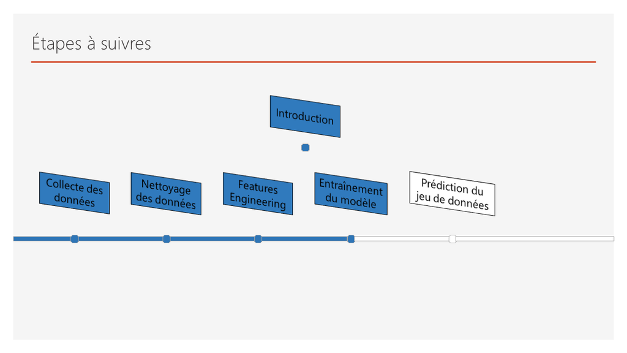

Comme expliqué dans la documentation officielle de Breiman, avec randomForest il n’y a pas besoin de cross-validation ou de test séparé pour un avoir une estimation des erreurs dans le jeu de test.  
Pour se faire une idée nous avons l’OOB error estimate.  
Vous pouvez retrouver l’explication complète ici https://www.stat.berkeley.edu/%7Ebreiman/RandomForests/cc_home.htm#ooberr

Passons donc à l’étape d’entraînement du modèle, pour commencer on va le faire avec les 10000 premières lignes pour que les temps de calculs soit convenable et en utilisant les paramètres par défaut.

```r
#Entraînement du modèle
system.time({
set.seed(123)

solo <- randomForest(winPlacePerc ~ ., data = head(trainsetSolo, 10000), na.action = na.omit, importance=T)})
```

```
##    user  system elapsed
##   62.94    0.04   63.00
```

```r
solo
```

```
##
## Call:
##  randomForest(formula = winPlacePerc ~ ., data = head(trainsetSolo,      10000), importance = T, na.action = na.omit)
##                Type of random forest: regression
##                      Number of trees: 500
## No. of variables tried at each split: 5
##
##           Mean of squared residuals: 0.005040281
##                     % Var explained: 94.23
```

Maintenant nous pouvons voir quelles variables ont le plus d’importance dans notre prédiction.

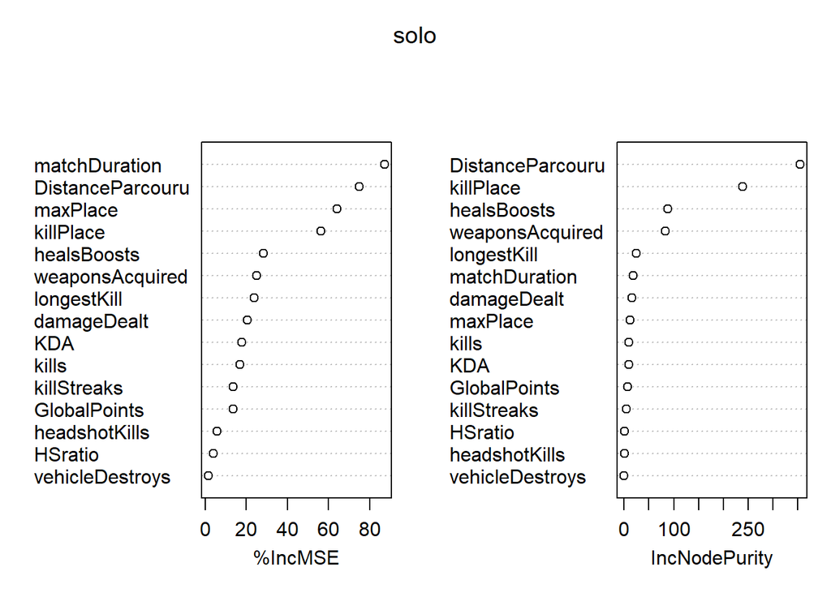

```r
varImpPlot(solo)
```

Ce qu’il faut interpréter ici c’est que plus une valeur est en haut de la liste plus elle est importante pour la prediction.  
La variable la plus importante semble être la DistanceParcouru, et c’est logique étant donné les compétences nécessaires pour le jeu.

Essayons maintenant de voir si on peut améliorer légérement tout ça en optimisant quelques valeurs comme le mtry et le ntree en utilisant la commande tuneRF.

Tout d’abord traçons le MSE (mean of squared residuals) en fonction du ntree, afin de trouver la valeur optimale pour le nombre d’arbres.

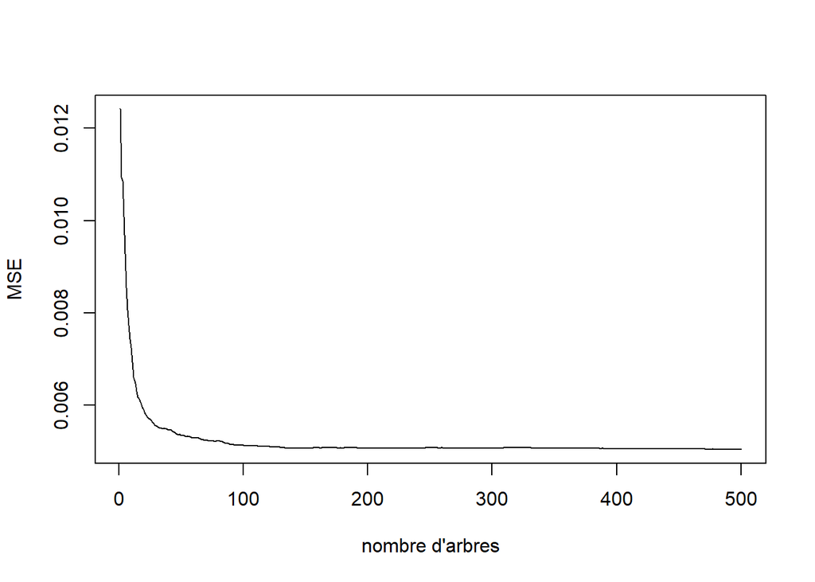

```r
plot(solo$mse, type = "l", xlab = "nombre d'arbres", ylab = "MSE")
```

```
## mtry = 5  OOB error = 0.005147019
## Searching left ...
## mtry = 4     OOB error = 0.00522416
## -0.01498762 0.001
## Searching right ...
## mtry = 7     OOB error = 0.005022129
## 0.0242645 0.001
## mtry = 10    OOB error = 0.005053426
## -0.00623192 0.001
```

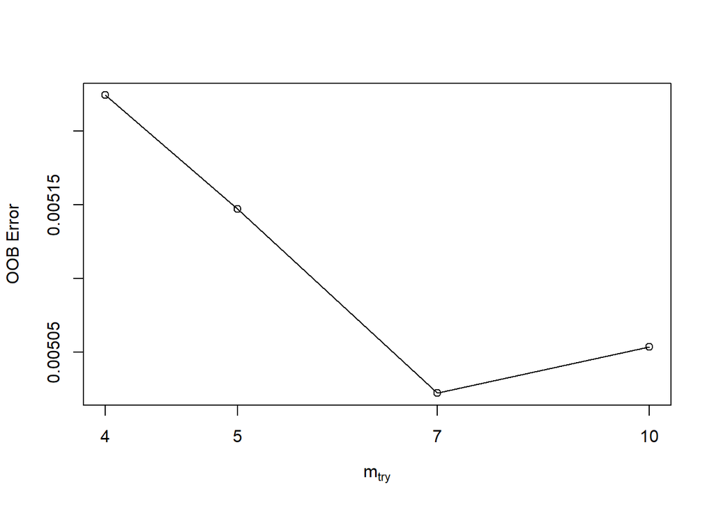

```r
soloPredictors <- trainsetSolo[, !(colnames(trainsetSolo) %in% c("winPlacePerc"))]
tuneRFtest <- tuneRF(head(soloPredictors, 10000), head(trainsetSolo$winPlacePerc, 10000), mtryStart=5, ntreeTry=200, stepFactor=1.5, improve=0.001,
       trace=TRUE, plot=TRUE, doBest=FALSE)
```

Le **mtry** optimal semble être 7.  
Relançons notre modèle d’entraînement avec ses paramètres.

```r
#Entraînement du modèle
system.time({
set.seed(123)

solo <- randomForest(winPlacePerc ~ ., data = head(trainsetSolo, 10000), na.action = na.omit, importance=T, mtry=7, ntree=200)})
```

```
##    user  system elapsed
##   31.68    0.00   31.70
```

```r
solo
```

```
##
## Call:
##  randomForest(formula = winPlacePerc ~ ., data = head(trainsetSolo,      10000), importance = T, mtry = 7, ntree = 200, na.action = na.omit)
##                Type of random forest: regression
##                      Number of trees: 200
## No. of variables tried at each split: 7
##
##           Mean of squared residuals: 0.004993675
##                     % Var explained: 94.28
```

C’est un tout petit peu mieux.  
A noter qu’il existe plusieurs moyens d’améliorer un modèle en Random Forest :  
- Utiliser plus de données, ici on a utiliser que les 10 000 premières lignes si on utiliser la totalité du dataset les résultats seraient meilleurs. - Le features engineering - Améliorer le mtry - Améliorer le ntree

##### Prédiction

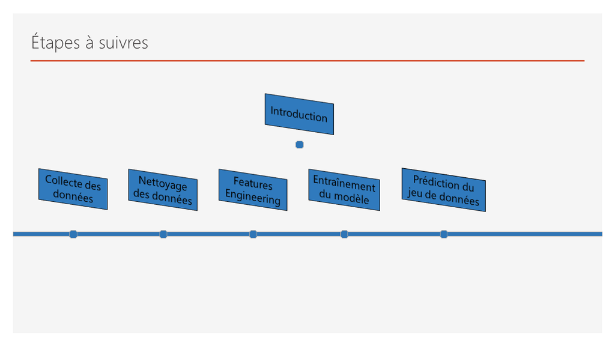

On va maintenant passer à la prédiction, on doit tout d’abord appliquer les mêmes modifications sur les variables dans le testSet et sortir les parties solo.

```r
#Ici on veut pouvoir retrouver le joueur donc on passe la colonne Id comme index des lignes.
rownames(testsetPUBG) <- testsetPUBG$Id
head(testsetPUBG, 10)
```

```
##                            Id        groupId        matchId assists boosts
## 9329eb41e215eb 9329eb41e215eb 676b23c24e70d6 45b576ab7daa7f       0      0
## 639bd0dcd7bda8 639bd0dcd7bda8 430933124148dd 42a9a0b906c928       0      4
## 63d5c8ef8dfe91 63d5c8ef8dfe91 0b45f5db20ba99 87e7e4477a048e       1      0
## cf5b81422591d1 cf5b81422591d1 b7497dbdc77f4a 1b9a94f1af67f1       0      0
## ee6a295187ba21 ee6a295187ba21 6604ce20a1d230 40754a93016066       0      4
## 3e2539b5d78183 3e2539b5d78183 029b5a79e08cd6 10186f5c852f62       0      0
## d812d2f1d88a02 d812d2f1d88a02 6285bb4eec83e4 f185809740a1a7       0      3
## a8a377e4d43bf8 a8a377e4d43bf8 61ec2e7730a3b8 d31adc82a4930e       0      0
## f18301e30d47d3 f18301e30d47d3 e7d609e08f09b6 bcde504ef16743       0      0
## ec7b965ef978b3 ec7b965ef978b3 c4c19ef6d6c6d9 6dc5b34c92d5ff       0      0
##                damageDealt DBNOs headshotKills heals killPlace killPoints kills
## 9329eb41e215eb     51.4600     0             0     0        73          0     0
## 639bd0dcd7bda8    179.1000     0             0     2        11          0     2
## 63d5c8ef8dfe91     23.4000     0             0     4        49          0     0
## cf5b81422591d1     65.5200     0             0     0        54          0     0
## ee6a295187ba21    330.2000     1             2     1         7          0     3
## 3e2539b5d78183      0.0000     0             0     0        89          0     0
## d812d2f1d88a02    470.7000     3             2    17         3          0     5
## a8a377e4d43bf8     68.6100     0             0     0        73          0     0
## f18301e30d47d3      0.0000     0             0     0        56          0     0
## ec7b965ef978b3     67.3200     0             0     0        54       1023     0
##                killStreaks longestKill matchDuration matchType maxPlace
## 9329eb41e215eb           0      0.0000          1884 squad-fpp       28
## 639bd0dcd7bda8           1    361.9000          1811   duo-fpp       48
## 63d5c8ef8dfe91           0      0.0000          1793 squad-fpp       28
## cf5b81422591d1           0      0.0000          1834   duo-fpp       45
## ee6a295187ba21           1     60.0600          1326 squad-fpp       28
## 3e2539b5d78183           0      0.0000          1775 squad-fpp       29
## d812d2f1d88a02           1     57.6100          1328   duo-fpp       49
## a8a377e4d43bf8           0      0.0000          1870 squad-fpp       29
## f18301e30d47d3           0      0.0000          1815 squad-fpp       28
## ec7b965ef978b3           0      0.0000          1336 squad-fpp       27
##                numGroups rankPoints revives rideDistance roadKills swimDistance
## 9329eb41e215eb        28       1500       0       0.0000         0       0.0000
## 639bd0dcd7bda8        47       1503       2    4669.0000         0       0.0000
## 63d5c8ef8dfe91        27       1565       0       0.0000         0       0.0000
## cf5b81422591d1        44       1465       0       0.0000         0       0.0000
## ee6a295187ba21        27       1480       1       0.0000         0       0.0000
## 3e2539b5d78183        29       1490       0       0.0000         0       0.0000
## d812d2f1d88a02        48       1538       0       0.0000         0       0.0000
## a8a377e4d43bf8        27       1487       0       0.0000         0       0.0000
## f18301e30d47d3        27       1640       0    2355.0000         0       0.0000
## ec7b965ef978b3        27         -1       0       0.0000         0       0.0000
##                teamKills vehicleDestroys walkDistance weaponsAcquired winPoints
## 9329eb41e215eb         0               0     588.0000               1         0
## 639bd0dcd7bda8         0               0    2017.0000               6         0
## 63d5c8ef8dfe91         0               0     787.8000               4         0
## cf5b81422591d1         0               0    1812.0000               3         0
## ee6a295187ba21         0               0    2963.0000               4         0
## 3e2539b5d78183         0               0       0.0000               0         0
## d812d2f1d88a02         0               0    1000.0000               4         0
## a8a377e4d43bf8         0               0    1217.0000               5         0
## f18301e30d47d3         0               0    1390.0000               7         0
## ec7b965ef978b3         0               0    1634.0000               5      1495
```

```r
#Transformer les colonnes character en valeurs numériques
testsetPUBG$damageDealt <- as.numeric(testsetPUBG$damageDealt)
testsetPUBG$longestKill <- as.numeric(testsetPUBG$longestKill)
testsetPUBG$rideDistance <- as.numeric(testsetPUBG$rideDistance)
testsetPUBG$swimDistance <- as.numeric(testsetPUBG$swimDistance)
testsetPUBG$walkDistance <- as.numeric(testsetPUBG$walkDistance)
#Features Engineering
testsetPUBG$DistanceParcouru = testsetPUBG$rideDistance + testsetPUBG$swimDistance + testsetPUBG$walkDistance
testsetPUBG$healsBoosts = testsetPUBG$heals + testsetPUBG$boosts
testsetPUBG$HSratio = testsetPUBG$headshotKills / testsetPUBG$kills
testsetPUBG$GlobalPoints = testsetPUBG$winPoints + testsetPUBG$killPoints + testsetPUBG$rankPoints
testsetPUBG$KDA = testsetPUBG$kills + testsetPUBG$assists/3
#suppression des colonnes désormais inutile
testsetPUBG = testsetPUBG[, !(colnames(testsetPUBG) %in% c("rideDistance","swimDistance","walkDistance","heals","boosts","Id","groupId","matchId","assists","winPoints","killPoints","rankPoints"))]
testsetPUBG[is.na(testsetPUBG)] <- 0
#Récupération des games en solo
vSolo <- c('flarefpp','flaretpp','crashfpp','crashtpp','normal-solo','normal-solo-fpp','solo-fpp')
testsetSolo <- filter(testsetPUBG, matchType %in% vSolo)
vDuo <- c('duo-fpp','normal-duo','normal-duo-fpp')
testsetDuo <- filter(testsetPUBG, matchType %in% vDuo)
vSquad <- c('normal-squad','normal-squad-fpp','squad-fpp')
testsetSquad <- filter(testsetPUBG, matchType %in% vSquad)
nrow(testsetSolo)
```

```
## [1] 239585
```

```r
nrow(testsetDuo)
```

```
## [1] 443351
```

```r
nrow(testsetSquad)
```

```
## [1] 756484
```

```r
#Suppression des dernières colonnes inutile
testsetSolo = testsetSolo[, !(colnames(testsetSolo) %in% c("groupId","DBNOs","matchType","numGroups","revives","teamKills"))]
testsetDuo = testsetDuo[, !(colnames(testsetDuo) %in% c("groupId","matchType","numGroups"))]
testsetSquad = testsetSquad[, !(colnames(testsetSquad) %in% c("groupId","matchType","numGroups"))]
```

On va lancer la prédiction de notre variable winPlacePerc dans le testsetSolo (pour les joueurs jouant en solo).

```r
predictionSolo <- predict(solo, testsetSolo)
```

```r
testsetSolo$winPlacePerc <- predictionSolo
summary(testsetSolo)
```

```
##   damageDealt      headshotKills       killPlace          kills
##  Min.   :   0.00   Min.   : 0.0000   Min.   :  1.00   Min.   : 0.0000
##  1st Qu.:   0.00   1st Qu.: 0.0000   1st Qu.: 24.00   1st Qu.: 0.0000
##  Median :  76.63   Median : 0.0000   Median : 48.00   Median : 0.0000
##  Mean   : 118.77   Mean   : 0.2479   Mean   : 48.12   Mean   : 0.9332
##  3rd Qu.: 172.00   3rd Qu.: 0.0000   3rd Qu.: 72.00   3rd Qu.: 1.0000
##  Max.   :2193.00   Max.   :10.0000   Max.   :100.00   Max.   :26.0000
##   killStreaks      longestKill     matchDuration     maxPlace
##  Min.   :0.0000   Min.   :  0.00   Min.   :  74   Min.   :  8.00
##  1st Qu.:0.0000   1st Qu.:  0.00   1st Qu.:1379   1st Qu.: 94.00
##  Median :0.0000   Median :  0.00   Median :1444   Median : 96.00
##  Mean   :0.4841   Mean   : 21.57   Mean   :1575   Mean   : 94.52
##  3rd Qu.:1.0000   3rd Qu.: 21.75   3rd Qu.:1862   3rd Qu.: 97.00
##  Max.   :7.0000   Max.   :888.10   Max.   :2194   Max.   :100.00
##    roadKills        vehicleDestroys    weaponsAcquired  DistanceParcouru
##  Min.   :0.000000   Min.   :0.000000   Min.   : 0.000   Min.   :    0.00
##  1st Qu.:0.000000   1st Qu.:0.000000   1st Qu.: 2.000   1st Qu.:   98.45
##  Median :0.000000   Median :0.000000   Median : 3.000   Median :  512.90
##  Mean   :0.007054   Mean   :0.004262   Mean   : 3.462   Mean   : 1373.04
##  3rd Qu.:0.000000   3rd Qu.:0.000000   3rd Qu.: 5.000   3rd Qu.: 2065.00
##  Max.   :7.000000   Max.   :5.000000   Max.   :41.000   Max.   :40799.92
##   healsBoosts        HSratio        GlobalPoints       KDA
##  Min.   : 0.000   Min.   :0.0000   Min.   : 100   Min.   : 0.0000
##  1st Qu.: 0.000   1st Qu.:0.0000   1st Qu.:1500   1st Qu.: 0.0000
##  Median : 0.000   Median :0.0000   Median :1562   Median : 0.0000
##  Mean   : 2.076   Mean   :0.1149   Mean   :1988   Mean   : 0.9537
##  3rd Qu.: 3.000   3rd Qu.:0.0000   3rd Qu.:2606   3rd Qu.: 1.0000
##  Max.   :66.000   Max.   :1.0000   Max.   :3730   Max.   :26.6667
##   winPlacePerc
##  Min.   :0.0005871
##  1st Qu.:0.2436592
##  Median :0.4935423
##  Mean   :0.4911763
##  3rd Qu.:0.7566150
##  Max.   :0.9920335
```

```r
head(testsetSolo, 10)
```

```
##                damageDealt headshotKills killPlace kills killStreaks
## 37ae98f31ca542        0.00             0        53     0           0
## 494d3d9fad73b2        0.00             0        87     0           0
## e59dd1435a2ecf      100.00             0        32     1           1
## 3e4413d4780f7c      100.00             0        41     1           1
## 7fc13cb6ff72da        0.00             0        60     0           0
## b912e5782b1e48        0.00             0        74     0           0
## fc6d38774da7b2        0.00             0        95     0           0
## 2f70df5da78353      170.60             1        20     1           1
## 86eff43fcbbb3c       44.72             0        92     0           0
## 2e0304c79f71b4       69.09             0        49     0           0
##                longestKill matchDuration maxPlace roadKills vehicleDestroys
## 37ae98f31ca542        0.00          1380       97         0               0
## 494d3d9fad73b2        0.00          1854       98         0               0
## e59dd1435a2ecf       25.23          1413       96         0               0
## 3e4413d4780f7c       36.26          1389       95         0               0
## 7fc13cb6ff72da        0.00          1404       99         0               0
## b912e5782b1e48        0.00          1449       98         0               0
## fc6d38774da7b2        0.00          1980       95         0               0
## 2f70df5da78353       24.22          1408       96         0               0
## 86eff43fcbbb3c        0.00          1350       96         0               0
## 2e0304c79f71b4        0.00          1827       94         0               0
##                weaponsAcquired DistanceParcouru healsBoosts HSratio
## 37ae98f31ca542               0            4.894           0       0
## 494d3d9fad73b2               2           82.110           0       0
## e59dd1435a2ecf               5          571.700           1       0
## 3e4413d4780f7c               1           28.490           0       0
## 7fc13cb6ff72da               0            4.330           0       0
## b912e5782b1e48               1          180.900           0       0
## fc6d38774da7b2               1            0.000           0       0
## 2f70df5da78353               4         4810.000           4       1
## 86eff43fcbbb3c               2           37.470           0       0
## 2e0304c79f71b4               4         2429.000           0       0
##                GlobalPoints KDA winPlacePerc
## 37ae98f31ca542         2564   0  0.558139387
## 494d3d9fad73b2         1499   0  0.106316754
## e59dd1435a2ecf         1488   1  0.577823192
## 3e4413d4780f7c         1567   1  0.142089325
## 7fc13cb6ff72da         2652   0  0.495466089
## b912e5782b1e48         2545   0  0.294869467
## fc6d38774da7b2         1523   0  0.005451264
## 2f70df5da78353         1584   1  0.889277767
## 86eff43fcbbb3c         1492   0  0.043031358
## 2e0304c79f71b4         1497   0  0.709263425
```

Si on prend par exemple le joueur **2f70df5da78353** qui a de bonnes chances de bien finir dans sa partie avec un **winPlacePerc** de 0.88 on voit que sur les variables les plus importante il a de bonnes statistiques avec une **DistanceParcouru** de 4810, 4 **armes ramassés**, et une **killPlace** de 20 la ou pour le joueur **494d3d9fad73b2** ça sera plus compliqué avec une **DistanceParcouru** de 82.1100 et une **killPlace** de 87 qui nous indique très certainement que le joueur est mort tôt.

Sans être exceptionnel notre modèle à l’air de se comporter correctement en vue des résultats.  
Un bon moyen d’améliorer un peu les performances seraient d’utiliser plus de données.  
Afin de pouvoir comparer l’impact de la quantité de données j’essairai si possible de mettre les résultat obtenu sur une plus grande partie du dataset.

##### Répéter les mêmes étapes pour le dataset duo et le dataset squad.

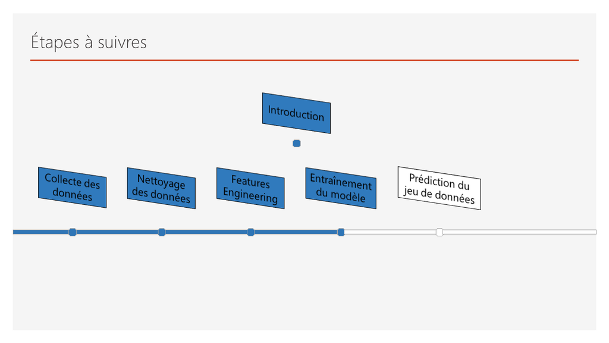

```r
#Nettoyage des dataframes, ce coup ci on garde les colonnes revives, teamKills, et DBNOs.
trainsetDuo = trainsetDuo[, !(colnames(trainsetDuo) %in% c("groupId","matchType","numGroups"))]
head(trainsetDuo, 10)
```

```
##    damageDealt DBNOs headshotKills killPlace kills killStreaks longestKill
## 1       137.90     1             0        64     0           0       0.000
## 2        80.71     1             0        72     0           0       0.000
## 3       269.10     0             1        18     2           1       7.438
## 4       192.30     1             2        15     2           1     280.600
## 5       558.60     3             0        11     3           2     237.500
## 6       381.20     2             1         7     4           2      42.130
## 7         0.00     0             0        82     0           0       0.000
## 8       318.00     2             0         5     4           2     103.600
## 9         0.00     0             0        86     0           0       0.000
## 10      529.30     3             0        12     3           2      20.100
##    matchDuration maxPlace revives teamKills vehicleDestroys weaponsAcquired
## 1           1384       48       0         0               0               1
## 2           1313       48       1         0               0               5
## 3           1890       48       1         0               0               5
```

[output cut: 18 more lines]

```r
trainsetSquad = trainsetSquad[, !(colnames(trainsetSquad) %in% c("groupId","matchType","numGroups"))]
head(trainsetSquad, 10)
```

```
##    damageDealt DBNOs headshotKills killPlace kills killStreaks longestKill
## 1         0.00     0             0        60     0           0       0.000
## 2        91.47     0             0        57     0           0       0.000
## 3        32.90     0             0        75     0           0       0.000
## 4       100.00     1             1        44     1           1      18.440
## 5         0.00     0             0        96     0           0       0.000
## 6        28.38     0             0        75     0           0       0.000
## 7         0.00     0             0        37     0           0       0.000
## 8       122.80     1             0        25     1           1      37.910
## 9        81.71     1             0        25     1           1       9.158
## 10        0.00     0             0        79     0           0       0.000
##    matchDuration maxPlace revives teamKills vehicleDestroys weaponsAcquired
## 1           1306       28       0         0               0               1
## 2           1777       26       0         0               0               5
## 3           1436       31       0         0               0               3
```

[output cut: 18 more lines]

```r
#Entraînement du modèle
system.time({
set.seed(123)

duo <- randomForest(winPlacePerc ~ ., data = head(trainsetDuo, 10000), na.action = na.omit, importance=T)})
```

```
##    user  system elapsed
##   70.97    0.05   71.08
```

```r
duo
```

```
##
## Call:
##  randomForest(formula = winPlacePerc ~ ., data = head(trainsetDuo,      10000), importance = T, na.action = na.omit)
##                Type of random forest: regression
##                      Number of trees: 500
## No. of variables tried at each split: 6
##
##           Mean of squared residuals: 0.007110755
##                     % Var explained: 92.06
```

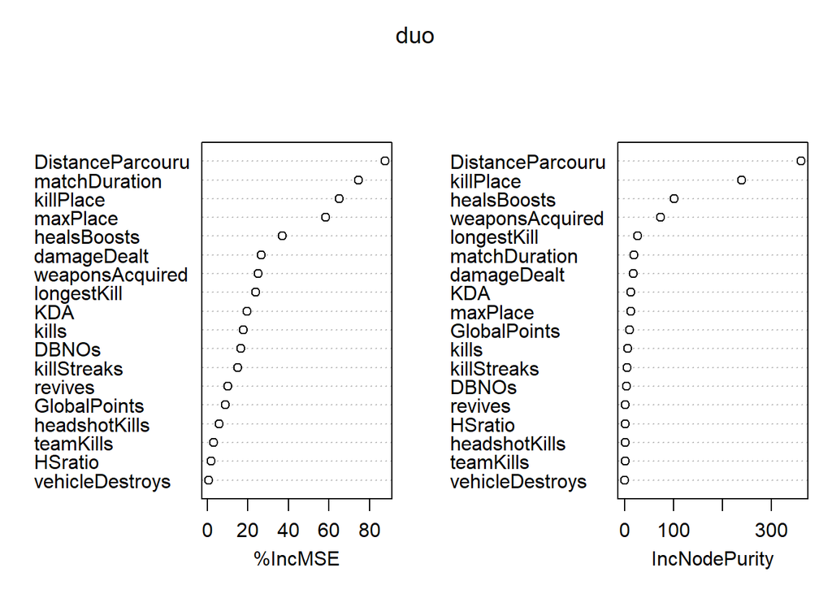

```r
#Impression de l'importance des variables
varImpPlot(duo)
```

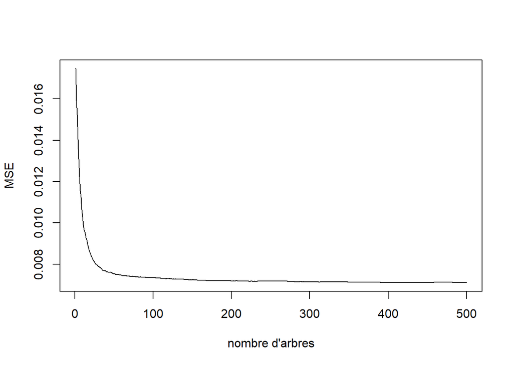

```r
#Vérification du ntree optimal
plot(duo$mse, type = "l", xlab = "nombre d'arbres", ylab = "MSE")
```

```
## mtry = 6  OOB error = 0.007092351
## Searching left ...
## mtry = 4     OOB error = 0.007443301
## -0.04948288 0.001
## Searching right ...
## mtry = 9     OOB error = 0.007099209
## -0.0009669199 0.001
```

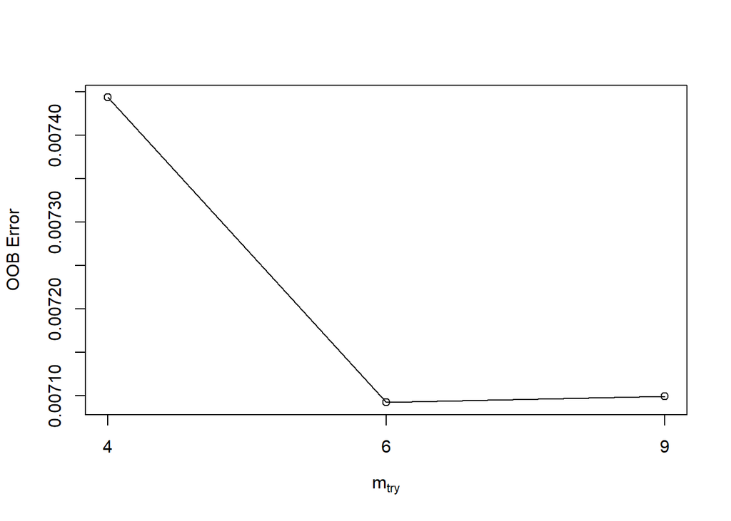

```r
#Vérification du mtry optimal
duoPredictors <- trainsetDuo[, !(colnames(trainsetDuo) %in% c("winPlacePerc"))]
tuneRFtest <- tuneRF(head(duoPredictors, 10000), head(trainsetDuo$winPlacePerc, 10000), mtryStart=6, ntreeTry=250, stepFactor=1.5, improve=0.001,
       trace=TRUE, plot=TRUE, doBest=FALSE)
```

```r
#Entraînement du modèle duo
system.time({
set.seed(123)

duo <- randomForest(winPlacePerc ~ ., data = head(trainsetDuo, 10000), na.action = na.omit, importance=T, mtry=9, ntree=250)})
```

```
##    user  system elapsed
##   46.39    0.05   46.47
```

```r
duo
```

```
##
## Call:
##  randomForest(formula = winPlacePerc ~ ., data = head(trainsetDuo,      10000), importance = T, mtry = 9, ntree = 250, na.action = na.omit)
##                Type of random forest: regression
##                      Number of trees: 250
## No. of variables tried at each split: 9
##
##           Mean of squared residuals: 0.007071762
##                     % Var explained: 92.1
```

```r
#Entraînement du modèle squad
system.time({
set.seed(123)

squad <- randomForest(winPlacePerc ~ ., data = head(trainsetSquad, 10000), na.action = na.omit, importance=T, mtry=9, ntree=250)})
```

```
##    user  system elapsed
##   46.65    0.03   46.72
```

```r
squad
```

```
##
## Call:
##  randomForest(formula = winPlacePerc ~ ., data = head(trainsetSquad,      10000), importance = T, mtry = 9, ntree = 250, na.action = na.omit)
##                Type of random forest: regression
##                      Number of trees: 250
## No. of variables tried at each split: 9
##
##           Mean of squared residuals: 0.01052935
##                     % Var explained: 89.11
```

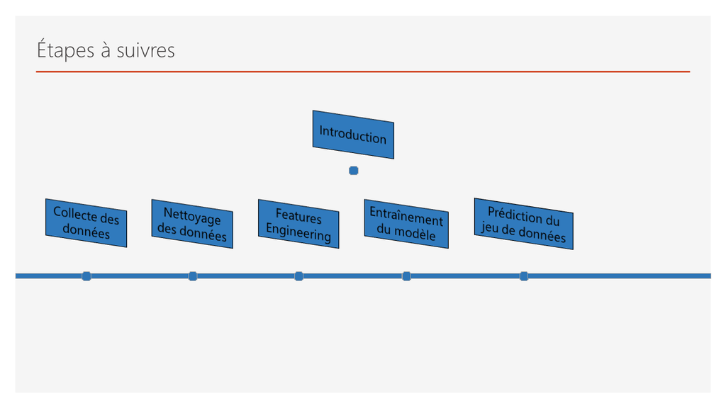

```r
predictionDuo <- predict(duo, testsetDuo)
predictionSquad <- predict(squad, testsetSquad)
```

```r
testsetDuo$winPlacePerc <- predictionDuo
head(testsetDuo, 10)
```

```
##                damageDealt DBNOs headshotKills killPlace kills killStreaks
## 639bd0dcd7bda8      179.10     0             0        11     2           1
## cf5b81422591d1       65.52     0             0        54     0           0
## d812d2f1d88a02      470.70     3             2         3     5           1
## 29da9623f0e316      140.20     0             0        33     1           1
## 2f42b452cf99f7      100.10     1             1        26     1           1
## 8ee93e13e67ae9        0.00     0             0        63     0           0
## d9463ae2916efb      100.00     1             0        80     0           0
## 8a706bc525a3cb       25.80     0             0        44     0           0
## a1cc5b6bae918e      200.00     1             0        21     2           1
## 2dd95ef76c1b7a       28.20     0             0        53     0           0
##                longestKill matchDuration maxPlace revives roadKills teamKills
## 639bd0dcd7bda8     361.900          1811       48       2         0         0
## cf5b81422591d1       0.000          1834       45       0         0         0
## d812d2f1d88a02      57.610          1328       49       0         0         0
## 29da9623f0e316       4.726          2066       47       0         0         0
## 2f42b452cf99f7      12.550          1956       49       0         0         0
## 8ee93e13e67ae9       0.000          1901       47       0         0         0
## d9463ae2916efb       0.000          1334       50       0         0         0
## 8a706bc525a3cb       0.000          1977       48       0         0         0
## a1cc5b6bae918e       9.826          1366       49       0         0         0
## 2dd95ef76c1b7a       0.000          1805       43       0         0         0
##                vehicleDestroys weaponsAcquired DistanceParcouru healsBoosts
## 639bd0dcd7bda8               0               6         6686.000           6
## cf5b81422591d1               0               3         1812.000           0
## d812d2f1d88a02               0               4         1000.000          20
## 29da9623f0e316               0               5          193.100           2
## 2f42b452cf99f7               0               5         7234.000          11
## 8ee93e13e67ae9               0               2           95.150           0
## d9463ae2916efb               0               2          164.700           2
## 8a706bc525a3cb               0               1         9649.000           1
## a1cc5b6bae918e               0               2          481.200           4
## 2dd95ef76c1b7a               0               3         6641.887           0
##                HSratio GlobalPoints      KDA winPlacePerc
## 639bd0dcd7bda8     0.0         1503 2.000000    0.8806467
## cf5b81422591d1     0.0         1465 0.000000    0.5249942
## d812d2f1d88a02     0.4         1538 5.000000    0.7050346
## 29da9623f0e316     0.0         1669 1.333333    0.2757930
## 2f42b452cf99f7     1.0         2957 1.000000    0.8053020
## 8ee93e13e67ae9     0.0         2499 0.000000    0.3735701
## d9463ae2916efb     0.0         2608 0.000000    0.2087911
## 8a706bc525a3cb     0.0         1547 0.000000    0.8197960
## a1cc5b6bae918e     0.0         2747 2.000000    0.4889460
## 2dd95ef76c1b7a     0.0         2592 0.000000    0.5436507
```

```r
testsetSquad$winPlacePerc <- predictionSquad
head(testsetSquad, 10)
```

```
##                damageDealt DBNOs headshotKills killPlace kills killStreaks
## 9329eb41e215eb       51.46     0             0        73     0           0
## 63d5c8ef8dfe91       23.40     0             0        49     0           0
## ee6a295187ba21      330.20     1             2         7     3           1
## 3e2539b5d78183        0.00     0             0        89     0           0
## a8a377e4d43bf8       68.61     0             0        73     0           0
## f18301e30d47d3        0.00     0             0        56     0           0
## ec7b965ef978b3       67.32     0             0        54     0           0
## 9a7777f1868aba        0.00     0             0        70     0           0
## aeded11e3d6daa      206.80     1             1         6     3           2
## 8b20f5b3995b98      301.00     3             1         5     4           1
##                longestKill matchDuration maxPlace revives roadKills teamKills
## 9329eb41e215eb        0.00          1884       28       0         0         0
## 63d5c8ef8dfe91        0.00          1793       28       0         0         0
## ee6a295187ba21       60.06          1326       28       1         0         0
## 3e2539b5d78183        0.00          1775       29       0         0         0
## a8a377e4d43bf8        0.00          1870       29       0         0         0
## f18301e30d47d3        0.00          1815       28       0         0         0
## ec7b965ef978b3        0.00          1336       27       0         0         0
## 9a7777f1868aba        0.00          1874       27       1         0         0
## aeded11e3d6daa       79.83          1381       27       1         0         1
## 8b20f5b3995b98       28.57          1378       27       2         0         0
##                vehicleDestroys weaponsAcquired DistanceParcouru healsBoosts
## 9329eb41e215eb               0               1            588.0           0
## 63d5c8ef8dfe91               0               4            787.8           4
## ee6a295187ba21               0               4           2963.0           5
## 3e2539b5d78183               0               0              0.0           0
## a8a377e4d43bf8               0               5           1217.0           0
## f18301e30d47d3               0               7           3745.0           0
## ec7b965ef978b3               0               5           1634.0           0
## 9a7777f1868aba               0               5           1127.0           0
## aeded11e3d6daa               0               6           2971.0           0
## 8b20f5b3995b98               0               2            300.2           0
##                  HSratio GlobalPoints       KDA winPlacePerc
## 9329eb41e215eb 0.0000000         1500 0.0000000 0.2378820867
## 63d5c8ef8dfe91 0.0000000         1565 0.3333333 0.5823572333
## ee6a295187ba21 0.6666667         1480 3.0000000 0.9081170333
## 3e2539b5d78183 0.0000000         1490 0.0000000 0.0009914938
## a8a377e4d43bf8 0.0000000         1487 0.0000000 0.2896525067
## f18301e30d47d3 0.0000000         1640 0.0000000 0.5769525333
## ec7b965ef978b3 0.0000000         2517 0.0000000 0.6120730867
## 9a7777f1868aba 0.0000000         1500 0.0000000 0.2876383733
## aeded11e3d6daa 0.3333333         1490 3.3333333 0.8161134133
## 8b20f5b3995b98 0.2500000         2746 4.3333333 0.4133880067
```

##### Compilation des résultats

```r
testsetSolo$Id <- rownames(testsetSolo)
testsetDuo$Id <- rownames(testsetDuo)
testsetSquad$Id <- rownames(testsetSquad)

resultSolo <- testsetSolo[, (colnames(testsetSolo) %in% c("Id","winPlacePerc"))]
resultDuo <- testsetDuo[, (colnames(testsetDuo) %in% c("Id","winPlacePerc"))]
resultSquad <- testsetSquad[, (colnames(testsetSquad) %in% c("Id","winPlacePerc"))]

results <- bind_rows(resultSolo, resultDuo)
results <- bind_rows(results, resultSquad)

rownames(results) <- NULL
results <- results[, c(2,1)]

head(results, 10)
```

```
##                Id winPlacePerc
## 1  37ae98f31ca542  0.558139387
## 2  494d3d9fad73b2  0.106316754
## 3  e59dd1435a2ecf  0.577823192
## 4  3e4413d4780f7c  0.142089325
## 5  7fc13cb6ff72da  0.495466089
## 6  b912e5782b1e48  0.294869467
## 7  fc6d38774da7b2  0.005451264
## 8  2f70df5da78353  0.889277767
## 9  86eff43fcbbb3c  0.043031358
## 10 2e0304c79f71b4  0.709263425
```

```r
write.csv(x = results, file = "PredictionPUBGResults.csv")
```

##### REFERENCES

http://mehdikhaneboubi.free.fr/random_forest_r.html https://www.rdocumentation.org/packages/randomForest/versions/4.6-14/topics/rfcv https://www.stat.berkeley.edu/%7Ebreiman/RandomForests/cc_home.html